# Step 2: Establishing a workflow for ATAC-seq-QC

Part A (step 2.1): What seurat normalization method should be used?

Xenia Sirodzha

2025-02-06

Here, I aimed to establish a workflow for ATAC-Seq-QC by performing typical ATAC-seq-QC steps on a reduced set of data. All steps were approved by Alexander Sasse.

To be precise, in this step, the data was normalized and pseudo-bulked using Seurat’s `AggregateExpression` function. To assess the effects of these transformations the data was partially visualized. Overall, the goal was to determine what normalization method, which is integrated into the `AggregateExpression` function from the Seurat package to use.

# Libraries

These are the packages required for the code below.

```r
library(tidyverse)
library(binom)
library(lubridate)
library(broom)
library(scales) #for scale transformations
```

```r
library(cowplot) #arranging plots
library(ggpubr)
library(ggridges)
library(ggthemes) #stylising plots
library(ggplot2)
library(ggsci)
library(wesanderson)
library(readxl) #for loading excel files
library(Seurat) #for rna-seq data, atac-seq data
library(Signac) #for atac seq data
```

# 1. Loading and inspecting

First, I loaded the sn-ATAC-seq Seurat Object, which contains the count matrix of 5 cell types and 1000 randomly selected peaks. More details about this Seurat Object can be found in “02-06-ATAC-Seq-Analysis-Step-1.1”.

```r
#loading file
sub_zfish_atac <- readRDS("Data/Lin_2023_zfish_snATAC-seq/sub_zfish_atac.rds")

#overview
glimpse(sub_zfish_atac) #overview over file
```

```
## Formal class 'Seurat' [package "SeuratObject"] with 13 slots
##   ..@ assays      :List of 1
##   .. ..$ atac:Formal class 'Assay5' [package "SeuratObject"] with 8 slots
##   ..@ meta.data   :'data.frame': 5514 obs. of  27 variables:
##   .. ..$ orig.ident       : Factor w/ 6 levels "10hpf","12hpf",..: 5 5 5 5 5 5 5 5 5 5 ...
##   .. ..$ nCount_atac      : num [1:5514] 214 147 181 170 124 114 108 128 105 125 ...
##   .. ..$ nFeature_atac    : int [1:5514] 94 72 74 75 61 55 52 60 51 54 ...
##   .. ..$ ...1             : chr [1:5514] "5hpf_1#5.25hpf_1_BC0021_N02" "5hpf_1#5.25hpf_1_BC0012_N01" "5hpf_1#5.25hpf_1_BC0018_N01" "5hpf_1#5.25hpf_1_BC0078_N02" ...
##   .. ..$ Sample           : chr [1:5514] "5hpf_1" "5hpf_1" "5hpf_1" "5hpf_1" ...
##   .. ..$ TSSEnrichment    : num [1:5514] 8.7 10.07 9.01 8.62 8.5 ...
##   .. ..$ ReadsInTSS       : num [1:5514] 3175 3524 2745 2755 1652 ...
##   .. ..$ ReadsInPromoter  : num [1:5514] 14232 14938 11951 11721 7048 ...
##   .. ..$ ReadsInBlacklist : num [1:5514] 0 0 0 0 0 0 0 0 0 0 ...
##   .. ..$ PromoterRatio    : num [1:5514] 0.0787 0.0861 0.0835 0.0988 0.0615 ...
##   .. ..$ PassQC           : num [1:5514] 1 1 1 1 1 1 1 1 1 1 ...
##   .. ..$ NucleosomeRatio  : num [1:5514] 1.16 1.23 1.08 1.22 1.2 ...
##   .. ..$ nMultiFrags      : num [1:5514] 17542 13440 12844 11903 11281 ...
##   .. ..$ nMonoFrags       : num [1:5514] 41913 38847 34432 26658 26007 ...
##   .. ..$ nFrags           : num [1:5514] 90396 86794 71572 59314 57328 ...
##   .. ..$ nDiFrags         : num [1:5514] 30941 34507 24296 20753 20040 ...
##   .. ..$ BlacklistRatio   : num [1:5514] 0 0 0 0 0 0 0 0 0 0 ...
##   .. ..$ stage            : chr [1:5514] "5hpf" "5hpf" "5hpf" "5hpf" ...
##   .. ..$ Clusters         : chr [1:5514] "C1" "C1" "C1" "C1" ...
##   .. ..$ ReadsInPeaks     : num [1:5514] 78617 77133 68699 61051 46438 ...
##   .. ..$ FRIP             : num [1:5514] 0.435 0.444 0.48 0.515 0.405 ...
##   .. ..$ celltype         : chr [1:5514] "YSL/presumptive endoderm" "YSL/presumptive endoderm" "YSL/presumptive endoderm" "YSL/presumptive endoderm" ...
##   .. ..$ predictedCell    : chr [1:5514] "6h_3 CELL4337_N1 _" "6h_2_CELL3455_N1" "6h_2_CELL3657_N1" "LC-5.3h-2_CELL2003_N1_LC-5.3h-2" ...
##   .. ..$ predictedGroup   : chr [1:5514] "YSL/endoderm" "YSL/endoderm" "YSL/endoderm" "YSL/endoderm" ...
##   .. ..$ predictedScore   : num [1:5514] 0.919 0.949 0.806 0.631 0.92 ...
##   .. ..$ DoubletScore     : num [1:5514] 22.2 44.5 323.3 293.3 0 ...
##   .. ..$ DoubletEnrichment: num [1:5514] 3.3 4.4 51.5 12.4 0.3 1.4 2.1 0.2 24.1 11.6 ...
##   ..@ active.assay: chr "atac"
##   ..@ active.ident: Factor w/ 6 levels "10hpf","12hpf",..: 5 5 5 5 5 5 5 5 5 5 ...
##   .. ..- attr(*, "names")= chr [1:5514] "5hpf_1#5.25hpf_1_BC0021_N02" "5hpf_1#5.25hpf_1_BC0012_N01" "5hpf_1#5.25hpf_1_BC0018_N01" "5hpf_1#5.25hpf_1_BC0078_N02" ...
##   ..@ graphs      : list()
##   ..@ neighbors   : list()
##   ..@ reductions  : list()
##   ..@ images      : list()
##   ..@ project.name: chr "SeuratProject"
##   ..@ misc        : list()
##   ..@ version     :Classes 'package_version', 'numeric_version'  hidden list of 1
##   .. ..$ : int [1:3] 5 0 2
##   ..@ commands    : list()
##   ..@ tools       : list()
```

```r
sub_zfish_atac@assays$atac$counts[1:10,1:2] #overview count matrix
```

```
## 10 x 2 sparse Matrix of class "dgCMatrix"
##                         5hpf_1#5.25hpf_1_BC0021_N02 5hpf_1#5.25hpf_1_BC0012_N01
## chr12:575791-576291                               .                           .
## chr20:8554541-8555041                             .                           .
## chr21:19062227-19062727                           .                           .
## chr5:40786396-40786896                            .                           .
## chr17:53328810-53329310                           .                           .
## chr14:21426958-21427458                           .                           .
## chr18:10952460-10952960                           .                           .
## chr23:21458886-21459386                           .                           .
## chr17:44203552-44204052                           .                           .
## chr2:56201692-56202192                            .                           .
```

Overall, this Seurat object contains both the count matrix and the meta data.

# 2. Pseudo bulking and normalization

At the start, I performed pseudo-bulking using Seurat’s `AggregateExpression` function. As, I was not sure which Seurat provided normalization method to use, I performed both logarithmic and centralized logarithmic normalization and looked whether and how the output differed.

To ensure that the randomized normalizations from Seurat are reproducible, I set a seed.

```r
## ensuring always the same random result
set.seed(59762489)

#testing if setting the seed worked
sample(1000,1) #running multiple times, same result
```

```
## [1] 684
```

Next, I pseudo-bulked and normalized the Seurat Object `sub_zfish_atac`. The values were aggregated by cell type.

```r
# Normalizing with Seurat
psd.bulk.sub_atc.clr= AggregateExpression(sub_zfish_atac, group.by = "celltype", normalization.method = "CLR", return.seurat = T)
```

```
## Normalizing across features
```

```r
psd.bulk.sub_atc.lgn= AggregateExpression(sub_zfish_atac, group.by = "celltype", normalization.method = "LogNormalize", return.seurat = T)
```

Then, I checked whether the pseudo-bulking worked as intended and whether the output differed. I expect that there will be only 5 columns left for the 5 cell types and that the output will differ

```r
#before pseudo bulking
dim(sub_zfish_atac@assays$atac)
```

```
## [1] 1000 5514
```

```r
#after pseudo bulking
dim(psd.bulk.sub_atc.clr$atac$counts) #values are stored in counts layer
```

```
## [1] 1000    5
```

```r
dim(psd.bulk.sub_atc.lgn$atac$counts)
```

```
## [1] 1000    5
```

```r
#testing if the output is identical
identical(psd.bulk.sub_atc.clr@assays$atac$data, psd.bulk.sub_atc.lgn@assays$atac$data)
```

```
## [1] FALSE
```

```r
#overview output
glimpse(psd.bulk.sub_atc.clr)
```

```
## Formal class 'Seurat' [package "SeuratObject"] with 13 slots
##   ..@ assays      :List of 1
##   .. ..$ atac:Formal class 'Assay5' [package "SeuratObject"] with 8 slots
##   ..@ meta.data   :'data.frame': 5 obs. of  2 variables:
##   .. ..$ orig.ident: chr [1:5] "lateral plate mesoderm" "neural crest" "periderm/epidermis" "primary neuron" ...
##   .. ..$ celltype  : chr [1:5] "lateral plate mesoderm" "neural crest" "periderm/epidermis" "primary neuron" ...
##   ..@ active.assay: chr "atac"
##   ..@ active.ident: Factor w/ 5 levels "lateral plate mesoderm",..: 1 2 3 4 5
##   .. ..- attr(*, "names")= chr [1:5] "lateral plate mesoderm" "neural crest" "periderm/epidermis" "primary neuron" ...
##   ..@ graphs      : list()
##   ..@ neighbors   : list()
##   ..@ reductions  : list()
##   ..@ images      : list()
##   ..@ project.name: chr "Aggregate"
##   ..@ misc        : list()
##   ..@ version     :Classes 'package_version', 'numeric_version'  hidden list of 1
##   .. ..$ : int [1:3] 5 0 2
##   ..@ commands    :List of 1
##   .. ..$ ScaleData.atac:Formal class 'SeuratCommand' [package "SeuratObject"] with 5 slots
##   ..@ tools       : list()
```

```r
glimpse(psd.bulk.sub_atc.lgn)
```

```
## Formal class 'Seurat' [package "SeuratObject"] with 13 slots
##   ..@ assays      :List of 1
##   .. ..$ atac:Formal class 'Assay5' [package "SeuratObject"] with 8 slots
##   ..@ meta.data   :'data.frame': 5 obs. of  2 variables:
##   .. ..$ orig.ident: chr [1:5] "lateral plate mesoderm" "neural crest" "periderm/epidermis" "primary neuron" ...
##   .. ..$ celltype  : chr [1:5] "lateral plate mesoderm" "neural crest" "periderm/epidermis" "primary neuron" ...
##   ..@ active.assay: chr "atac"
##   ..@ active.ident: Factor w/ 5 levels "lateral plate mesoderm",..: 1 2 3 4 5
##   .. ..- attr(*, "names")= chr [1:5] "lateral plate mesoderm" "neural crest" "periderm/epidermis" "primary neuron" ...
##   ..@ graphs      : list()
##   ..@ neighbors   : list()
##   ..@ reductions  : list()
##   ..@ images      : list()
##   ..@ project.name: chr "Aggregate"
##   ..@ misc        : list()
##   ..@ version     :Classes 'package_version', 'numeric_version'  hidden list of 1
##   .. ..$ : int [1:3] 5 0 2
##   ..@ commands    :List of 1
##   .. ..$ ScaleData.atac:Formal class 'SeuratCommand' [package "SeuratObject"] with 5 slots
##   ..@ tools       : list()
```

The outputs meet the expectations.

# 3 Assessement of transformation by visualization by celltype

## 3.1 Data wrangling for visualization

Next, to assess if the transformation is suitable for quality control, I analysed and visualised the data.

To achieve this, the normalised counts needed to be extracted and converted into a ggplot tidyverse compatible format: a data frame. I performed analysis and visualization for both counts in an analogical manner.

First, I calculated the sum of all peaks and the coefficient of variance (cv).

```r
## extracting tibbles

# CLR
df_psd.bulk_atc.clr=as_tibble(psd.bulk.sub_atc.clr@assays$atac$data, rownames="rownames")

# LogNormalize

df_psd.bulk_atc.lgn=as_tibble(psd.bulk.sub_atc.lgn@assays$atac$data, rownames="rownames")


## calculating sum over all peaks and coefficient of variance of all peaks

# CLR:
df_psd.bulk_atc.clr %>%
  pivot_longer(cols=!contains("rownames"), ,values_to = "pk_counts", names_to = "celltype") %>%
  mutate(pk_count_sum= sum(pk_counts)) %>%
  mutate(cv=sd(pk_counts) / mean(pk_counts)) %>%
  group_by(celltype) %>%
  mutate(pk_count_sum_celltype= sum(pk_counts)) %>%
  mutate(cv_celltype=sd(pk_counts) / mean(pk_counts)) %>%
  mutate(all="all celltypes")-> df_psd.bulk_atc.clr

# LogNormalize

df_psd.bulk_atc.lgn %>%
  pivot_longer(cols=!contains("rownames"), ,values_to = "pk_counts", names_to = "celltype") %>%
  mutate(pk_count_sum= sum(pk_counts)) %>%
  mutate(cv=sd(pk_counts) / mean(pk_counts)) %>%
  group_by(celltype) %>%
  mutate(pk_count_sum_celltype= sum(pk_counts)) %>%
  mutate(cv_celltype=sd(pk_counts) / mean(pk_counts)) %>%
  mutate(all="all celltypes")-> df_psd.bulk_atc.lgn
```

This code results in two data sets which have identical column names.

```r
df_psd.bulk_atc.clr
```

| rownames | celltype | pk_counts | pk_count_sum | cv | pk_count_sum_celltype | cv_celltype | all |
| --- | --- | --- | --- | --- | --- | --- | --- |
| chr12:575791-576291 | lateral plate mesoderm | 0.23983110 | 3522.827 | 0.607022 | 570.3778 | 0.5557057 | all celltypes |
| chr12:575791-576291 | neural crest | 0.96554049 | 3522.827 | 0.607022 | 685.2171 | 0.5176809 | all celltypes |
| chr12:575791-576291 | periderm/epidermis | 0.85661388 | 3522.827 | 0.607022 | 600.5949 | 0.6421017 | all celltypes |
| chr12:575791-576291 | primary neuron | 0.23983110 | 3522.827 | 0.607022 | 756.4660 | 0.5454479 | all celltypes |
| chr12:575791-576291 | YSL/presumptive endoderm | 1.15318748 | 3522.827 | 0.607022 | 910.1711 | 0.5975685 | all celltypes |
| chr20:8554541-8555041 | lateral plate mesoderm | 0.00000000 | 3522.827 | 0.607022 | 570.3778 | 0.5557057 | all celltypes |
| chr20:8554541-8555041 | neural crest | 0.39213862 | 3522.827 | 0.607022 | 685.2171 | 0.5176809 | all celltypes |
| chr20:8554541-8555041 | periderm/epidermis | 0.00000000 | 3522.827 | 0.607022 | 600.5949 | 0.6421017 | all celltypes |
| chr20:8554541-8555041 | primary neuron | 2.29078000 | 3522.827 | 0.607022 | 756.4660 | 0.5454479 | all celltypes |
| chr20:8554541-8555041 | YSL/presumptive endoderm | 1.22398552 | 3522.827 | 0.607022 | 910.1711 | 0.5975685 | all celltypes |

[output cut: 4990 more lines]

```r
df_psd.bulk_atc.lgn
```

| rownames | celltype | pk_counts | pk_count_sum | cv | pk_count_sum_celltype | cv_celltype | all |
| --- | --- | --- | --- | --- | --- | --- | --- |
| chr12:575791-576291 | lateral plate mesoderm | 0.6570806 | 8914.022 | 0.5475271 | 1761.801 | 0.5773019 | all celltypes |
| chr12:575791-576291 | neural crest | 1.6576347 | 8914.022 | 0.5475271 | 1753.415 | 0.5712692 | all celltypes |
| chr12:575791-576291 | periderm/epidermis | 1.7427796 | 8914.022 | 0.5475271 | 1783.039 | 0.5408068 | all celltypes |
| chr12:575791-576291 | primary neuron | 0.5384168 | 8914.022 | 0.5475271 | 1836.241 | 0.5127150 | all celltypes |
| chr12:575791-576291 | YSL/presumptive endoderm | 1.6317459 | 8914.022 | 0.5475271 | 1779.526 | 0.5360066 | all celltypes |
| chr20:8554541-8555041 | lateral plate mesoderm | 0.0000000 | 8914.022 | 0.5475271 | 1761.801 | 0.5773019 | all celltypes |
| chr20:8554541-8555041 | neural crest | 0.5352143 | 8914.022 | 0.5475271 | 1753.415 | 0.5712692 | all celltypes |
| chr20:8554541-8555041 | periderm/epidermis | 0.0000000 | 8914.022 | 0.5475271 | 1783.039 | 0.5408068 | all celltypes |
| chr20:8554541-8555041 | primary neuron | 2.6529536 | 8914.022 | 0.5475271 | 1836.241 | 0.5127150 | all celltypes |
| chr20:8554541-8555041 | YSL/presumptive endoderm | 1.2727045 | 8914.022 | 0.5475271 | 1779.526 | 0.5360066 | all celltypes |

[output cut: 4990 more lines]

To plot a histogram, I also require the counts of all cells in a long format. This is achieved with the code below.

```r
df_pk_mtrx= as_tibble(sub_zfish_atac$atac$counts, rownames="rownames")
df_pk_mtrx %>% pivot_longer(cols=!contains("rownames"), ,values_to = "pk_counts", names_to = "id") -> df_pk_mtrx.l
df_pk_mtrx.l
```

| rownames | id | pk_counts |
| --- | --- | --- |
| chr12:575791-576291 | 5hpf_1#5.25hpf_1_BC0021_N02 | 0 |
| chr12:575791-576291 | 5hpf_1#5.25hpf_1_BC0012_N01 | 0 |
| chr12:575791-576291 | 5hpf_1#5.25hpf_1_BC0018_N01 | 0 |
| chr12:575791-576291 | 5hpf_1#5.25hpf_1_BC0078_N02 | 0 |
| chr12:575791-576291 | 5hpf_1#5.25hpf_1_BC0044_N01 | 0 |
| chr12:575791-576291 | 5hpf_1#5.25hpf_1_BC0065_N02 | 0 |
| chr12:575791-576291 | 5hpf_1#5.25hpf_1_BC0123_N02 | 0 |
| chr12:575791-576291 | 5hpf_1#5.25hpf_1_BC0075_N02 | 0 |
| chr12:575791-576291 | 5hpf_1#5.25hpf_1_BC0140_N02 | 0 |
| chr12:575791-576291 | 5hpf_1#5.25hpf_1_BC0154_N02 | 0 |

[output cut: 9990 more lines]

## 3.2 Visualization

Here, the data was visualized to assess what normalization method to use for ATAC-Seq-QC. All plots were generated using the tidyverse ggplot package.

### 3.2.1 Cell counts histogram before transformation

I plotted counts before transformation as a histogram.

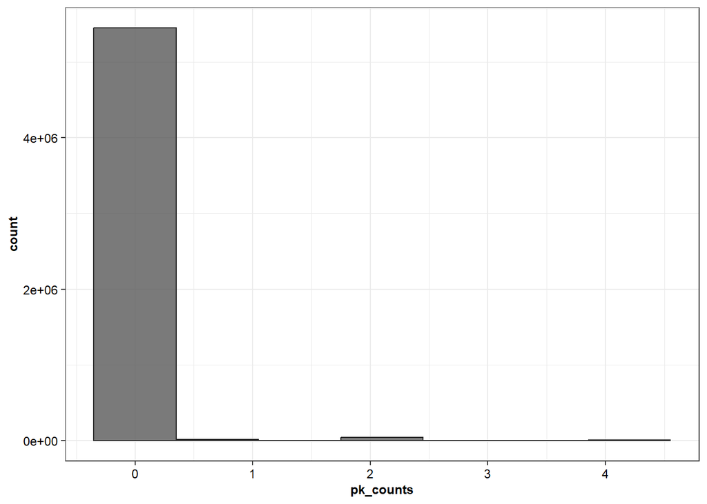

```r
df_pk_mtrx.l %>%
  ggplot(aes(x=pk_counts))+geom_histogram(binwidth = 0.7, color="gray15", alpha=0.8)+
  theme_bw()+ theme(text = element_text(size = 9, family="sans", color="black"), #stylisation
        axis.text = element_text(size=9, color="black"),
        axis.title=element_text(size=9, face = "bold"),
        plot.subtitle=element_text(size=10.5),
        plot.title=element_text(size=11, face = "bold"),
        legend.position ="none")
```

Most values were 0 therefore, I excluded them before plotting again.

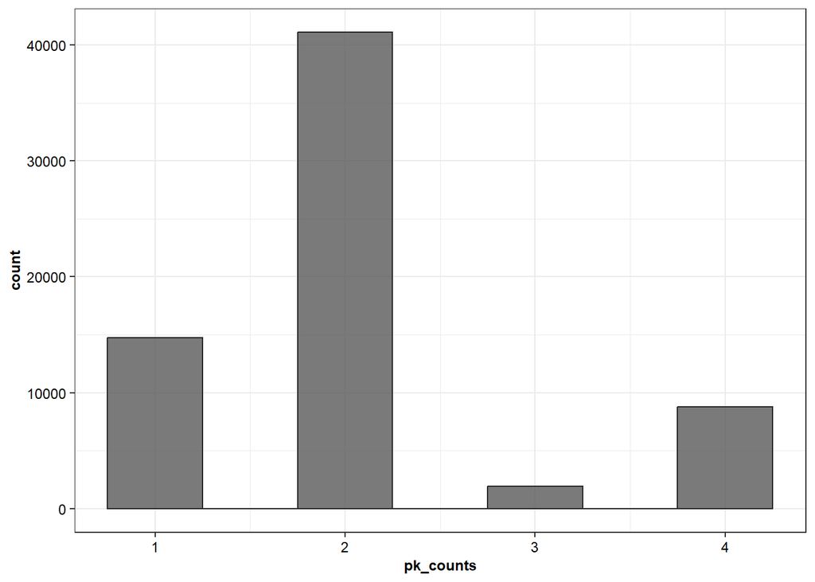

```r
df_pk_mtrx.l %>%
  filter(pk_counts!=0) %>%
  ggplot(aes(x=pk_counts))+geom_histogram(binwidth = 0.5, color="gray15", alpha=0.8)+
  theme_bw()+ theme(text = element_text(size = 9, family="sans", color="black"), #stylisation
        axis.text = element_text(size=9, color="black"),
        axis.title=element_text(size=9, face = "bold"),
        plot.subtitle=element_text(size=10.5),
        plot.title=element_text(size=11, face = "bold"),
        legend.position ="none")
```

### 3.2.2 Visualization of “CLR”

In this section, the CLR normalized data was visualized.

#### 3.2.2.1 Distribution after pseudo-bulking by celltype

Counts were plotted in a histogram overall and then by cell type.

```r
# Overall

df_psd.bulk_atc.clr %>%
 ggplot(aes(x=pk_counts))+geom_histogram(binwidth = 0.2, color="gray15", alpha=0.8)+
 scale_y_continuous(breaks = scales::breaks_pretty(n=10))+
  coord_fixed(ratio = 0.01)+
  theme_bw()+ theme(text = element_text(size = 9, family="sans", color="black"), #stylisation
        axis.text = element_text(size=9, color="black"),
        axis.title=element_text(size=9, face = "bold"),
        plot.subtitle=element_text(size=10.5),
        plot.title=element_text(size=11, face = "bold"),
        legend.position ="none") ->dis.counts.clr


# by cell type

 ggplot(df_psd.bulk_atc.clr, aes(x=pk_counts, fill = celltype))+
  geom_histogram(binwidth = 0.2, color="gray15", alpha=0.8)+
  scale_y_continuous(breaks = scales::breaks_pretty(n=10))+
  facet_wrap(facets = "celltype")+
  theme_bw()+ theme(text = element_text(size = 9, family="sans", color="black"), #stylisation
        axis.text = element_text(size=9, color="black"),
        axis.title=element_text(size=9, face = "bold"),
        plot.subtitle=element_text(size=10.5),
        plot.title=element_text(size=11, face = "bold"),
        legend.position ="none") ->dis.counts.cell.clr
```

They were arranged below.

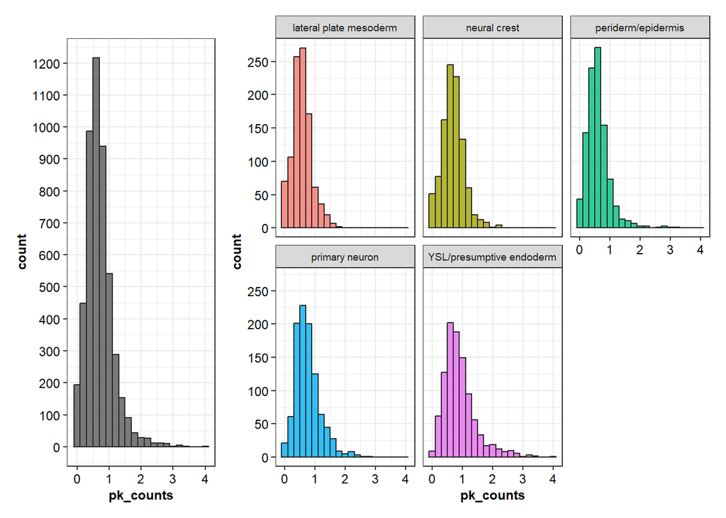

```r
dis.counts.clr|dis.counts.cell.clr
```

Generally, counts are somewhat normally distributed. There are no cell type specific trends. However, most counts are between the values 0 and 1.5 which is not typical for well normalized ATAC-seq-data.

#### 3.2.2.2 Sum of all peaks

I counted and visualized the sum of all peaks by cell type and in general.

```r
unique(df_psd.bulk_atc.clr$pk_count_sum)
```

```
## [1] 3522.827
```

The sums of all peaks were visualized in a barplot, analogically to the visualization by histogram

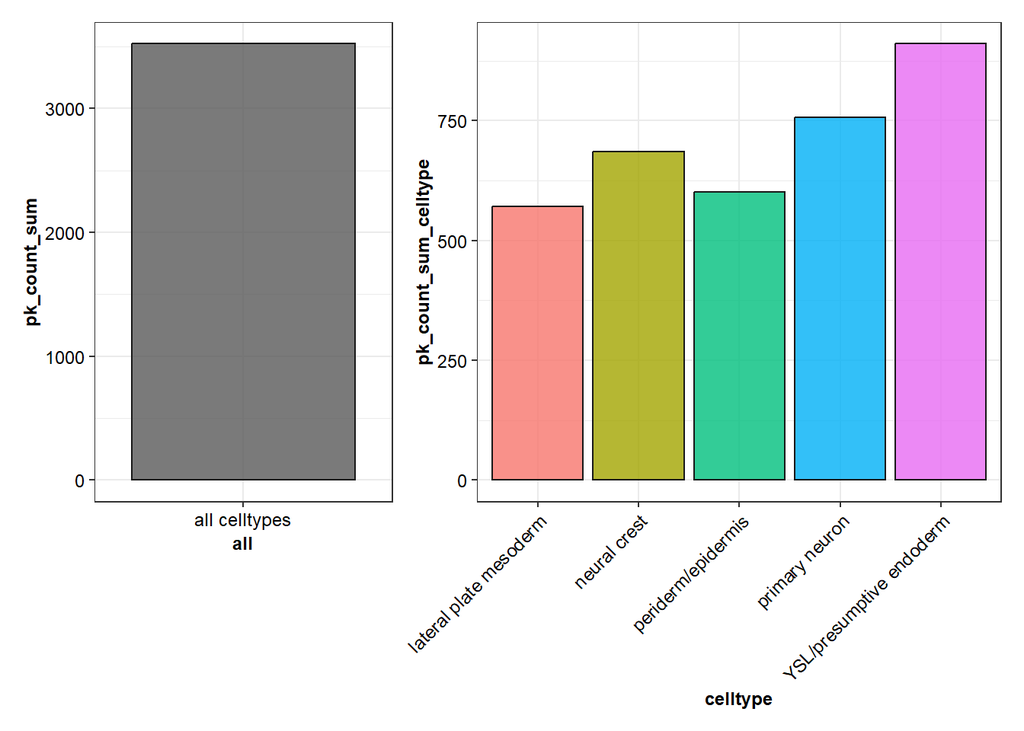

```r
# Overall

df_psd.bulk_atc.clr %>%
  ungroup() %>%
  distinct(all, pk_count_sum) %>%
  ggplot(aes(x=all, y=pk_count_sum))+
  geom_col(alpha=0.8, color="gray10")+
  coord_fixed(ratio = 0.0005)+
  theme_bw()+ theme(text = element_text(size = 9, family="sans", color="black"), #stylisation
        axis.text = element_text(size=9, color="black"),
        axis.title=element_text(size=9, face = "bold"),
        plot.subtitle=element_text(size=10.5),
        plot.title=element_text(size=11, face = "bold"),
        legend.position ="none") -> sum.peaks.all.clr


# by cell type

df_psd.bulk_atc.clr %>%
  group_by(celltype) %>%
  distinct(pk_count_sum_celltype, pk_count_sum) %>%
  ggplot(aes(x=celltype, y=pk_count_sum_celltype, fill=celltype))+
  geom_col(alpha=0.8, color="gray10")+
  theme_bw()+ theme(text = element_text(size = 9, family="sans", color="black"), #stylisation
        axis.text = element_text(size=9, color="black"),
        axis.title=element_text(size=9, face = "bold"),
        axis.text.x = element_text(angle = 45, hjust = 1),
        plot.subtitle=element_text(size=10.5),
        plot.title=element_text(size=11, face = "bold"),
        legend.position ="none") -> sum.peaks.celltype.clr

sum.peaks.all.clr|sum.peaks.celltype.clr
```

#### 3.2.2.3 Coefficient of variation

The coefficient of variation was visualized as the sum of all peaks previously.

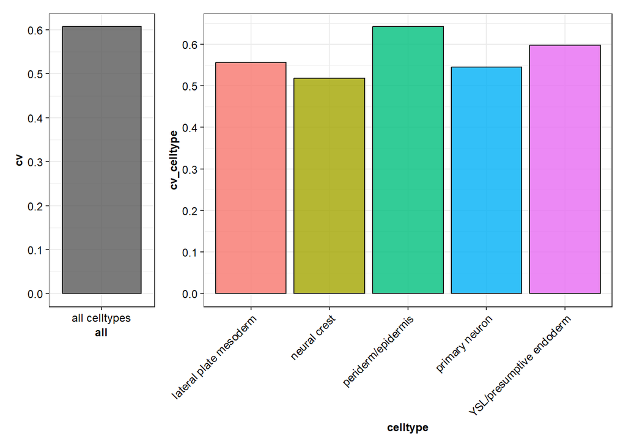

```r
# Overall

df_psd.bulk_atc.clr %>%
  ungroup() %>%
  distinct(all, cv) %>%
  ggplot(aes(x=all, y=cv ))+
  geom_col(alpha=0.8, color="gray10")+
  scale_y_continuous(n.breaks=10)+
  coord_fixed(ratio = 5)+
  theme_bw()+ theme(text = element_text(size = 9, family="sans", color="black"), #stylisation
        axis.text = element_text(size=9, color="black"),
        axis.title=element_text(size=9, face = "bold"),
        plot.subtitle=element_text(size=10.5),
        plot.title=element_text(size=11, face = "bold"),
        legend.position ="none") -> cv.all.clr


# by cell type

df_psd.bulk_atc.clr %>%
  group_by(celltype) %>%
  distinct(cv_celltype, cv) %>%
  ggplot(aes(x=celltype, y=cv_celltype, fill=celltype))+
  geom_col(alpha=0.8, color="gray10")+
  scale_y_continuous(n.breaks=10)+
  theme_bw()+ theme(text = element_text(size = 9, family="sans", color="black"), #stylisation
        axis.text = element_text(size=9, color="black"),
        axis.title=element_text(size=9, face = "bold"),
        axis.text.x = element_text(angle = 45, hjust = 1),
        plot.subtitle=element_text(size=10.5),
        plot.title=element_text(size=11, face = "bold"),
        legend.position ="none") ->cv.celltype.clr

cv.all.clr|cv.celltype.clr
```

Overall, coefficients of variation of each cell type are very similar to one another and to the coefficient of variation of all cells. However, periderm/epidermis cells have the highest coefficient of variation.

#### 3.2.2.4 Count distribution by cell type

Then, just as previously count distribution was visualized with a violin plot.

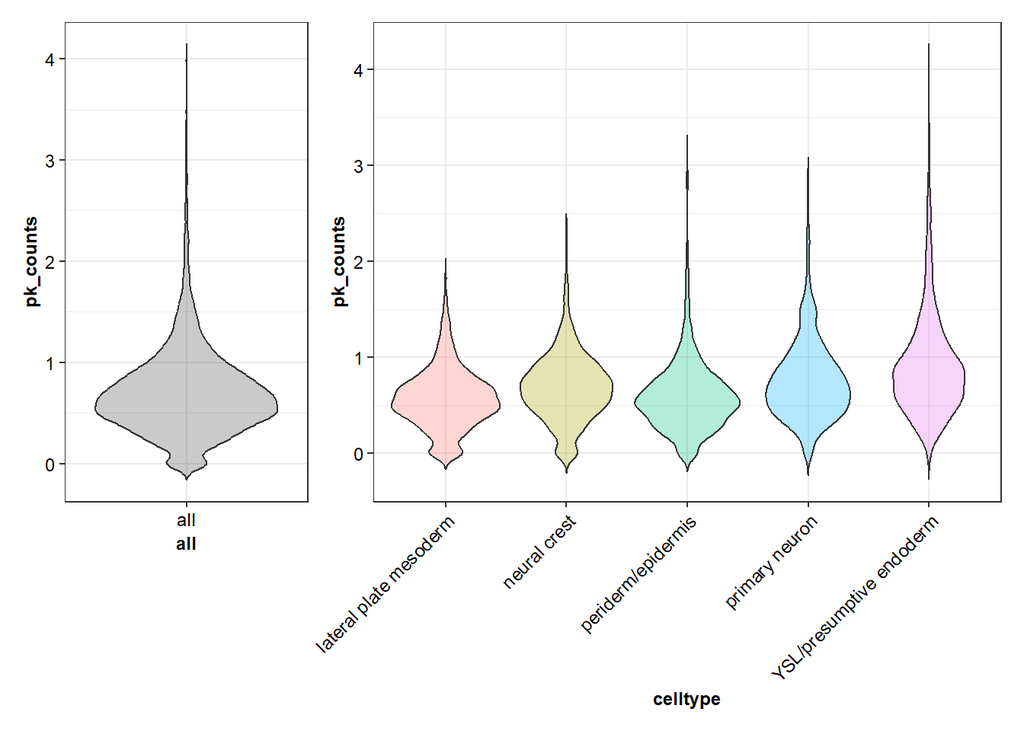

```r
df_psd.bulk_atc.clr %>%
  mutate(all="all") %>%
 ggplot( aes( x=all, y=pk_counts))+
  geom_violin(color="grey20", alpha=0.3, fill="gray30", trim=F)+
  coord_fixed(ratio = 0.5)+
   scale_y_continuous(breaks = seq(0,10,1))+ #y-axis more easily readable
  theme_bw()+ theme(text = element_text(size = 9, family="sans", color="black"), #stylisation
        axis.text = element_text(size=9, color="black"),
        axis.title=element_text(size=9, face = "bold"),
        plot.subtitle=element_text(size=10.5),
        plot.title=element_text(size=11, face = "bold"),
        legend.position ="none") -> v.plot.all.clr


 ggplot(df_psd.bulk_atc.clr, aes(x=celltype, y=pk_counts, fill = celltype))+
  geom_violin(color="grey20", alpha=0.3, trim=F)+
    scale_y_continuous(breaks = seq(0,10,1))+ #y-axis more easily readable
  theme_bw()+ theme(text = element_text(size = 9, family="sans", color="black"), #stylisation
        axis.text = element_text(size=9, color="black"),
        axis.text.x = element_text(angle = 45, hjust = 1),
        axis.title=element_text(size=9, face = "bold"),
        plot.subtitle=element_text(size=10.5),
        plot.title=element_text(size=11, face = "bold"),
        legend.position ="none") -> v.plot.cells.clr

 v.plot.all.clr|v.plot.cells.clr
```

To visualise median and quantiles, a boxplot was added.

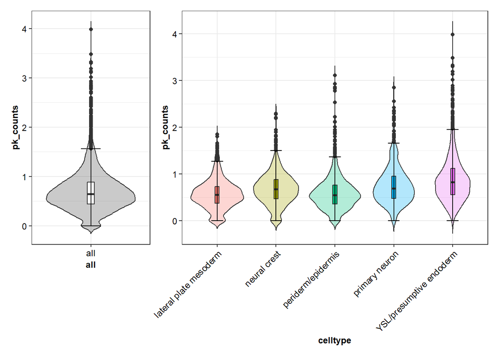

```r
df_psd.bulk_atc.clr %>%
  mutate(all="all") %>%
 ggplot( aes( x=all, y=pk_counts))+
  geom_violin(color="grey20", alpha=0.3, fill="gray30", trim=F)+
  geom_boxplot(width = 0.07)+
  stat_boxplot(geom ='errorbar', width=0.2, position=position_dodge(0.5))+
   scale_y_continuous(breaks = seq(0,10,1))+ #y-axis more easily readable
  coord_fixed(ratio = 0.5)+
  theme_bw()+ theme(text = element_text(size = 9, family="sans", color="black"), #stylisation
        axis.text = element_text(size=9, color="black"),
        axis.title=element_text(size=9, face = "bold"),
        plot.subtitle=element_text(size=10.5),
        plot.title=element_text(size=11, face = "bold"),
        legend.position ="none") -> v.plot.all.box.clr


 ggplot(df_psd.bulk_atc.clr, aes(x=celltype, y=pk_counts, fill = celltype))+
  geom_violin(color="grey20", alpha=0.3, trim=F)+
  geom_boxplot(width = 0.07)+
  stat_boxplot(geom ='errorbar', width=0.2, position=position_dodge(0.5))+
    scale_y_continuous(breaks = seq(0,10,1))+ #y-axis more easily readable
  theme_bw()+ theme(text = element_text(size = 9, family="sans", color="black"), #stylisation
        axis.text = element_text(size=9, color="black"),
        axis.text.x = element_text(angle = 45, hjust = 1),
        axis.title=element_text(size=9, face = "bold"),
        plot.subtitle=element_text(size=10.5),
        plot.title=element_text(size=11, face = "bold"),
        legend.position ="none") -> v.plot.cells.box.clr

 v.plot.all.box.clr|v.plot.cells.box.clr
```

The distribution of counts of all celltypes is very similar to each other and the distribution of counts overall. The YSL/presumptive endoderm cells have slightly higher counts overall. Most counts range from 0.5 to 1 and are centered around approximately 0.6.

### 3.2.3 Visualization of “LogNormalize”

In this section, the LogNormalize normalized data was visualized analogically to CLR normalized data (chapter 3.2.2).

#### 3.2.3.1 Distribution after pseudo-bulking by celltype

Counts were plotted in a histogram overall and then by cell type.

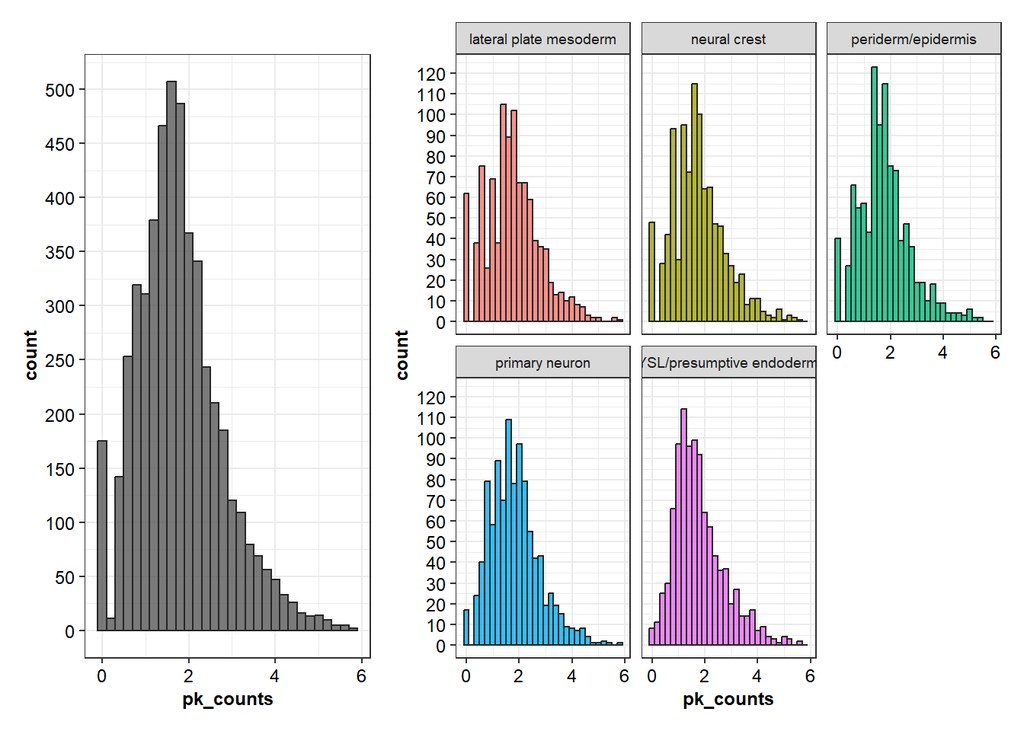

```r
# Overall

df_psd.bulk_atc.lgn %>%
 ggplot(aes(x=pk_counts))+geom_histogram(binwidth = 0.2, color="gray15", alpha=0.8)+
 scale_y_continuous(breaks = scales::breaks_pretty(n=10))+
  coord_fixed(ratio = 0.025)+
  theme_bw()+ theme(text = element_text(size = 9, family="sans", color="black"), #stylisation
        axis.text = element_text(size=9, color="black"),
        axis.title=element_text(size=9, face = "bold"),
        plot.subtitle=element_text(size=10.5),
        plot.title=element_text(size=11, face = "bold"),
        legend.position ="none") ->dis.counts.lgn


# by cell type

 ggplot(df_psd.bulk_atc.lgn, aes(x=pk_counts, fill = celltype))+
  geom_histogram(binwidth = 0.2, color="gray15", alpha=0.8)+
  scale_y_continuous(breaks = scales::breaks_pretty(n=10))+
  facet_wrap(facets = "celltype")+
  theme_bw()+ theme(text = element_text(size = 9, family="sans", color="black"), #stylisation
        axis.text = element_text(size=9, color="black"),
        axis.title=element_text(size=9, face = "bold"),
        plot.subtitle=element_text(size=10.5),
        plot.title=element_text(size=11, face = "bold"),
        legend.position ="none") ->dis.counts.cell.lgn

dis.counts.lgn|dis.counts.cell.lgn
```

#### 3.2.3.2 Sum of all peaks

```r
unique(df_psd.bulk_atc.lgn$pk_count_sum)
```

```
## [1] 8914.022
```

Bar plot sum of all peaks.

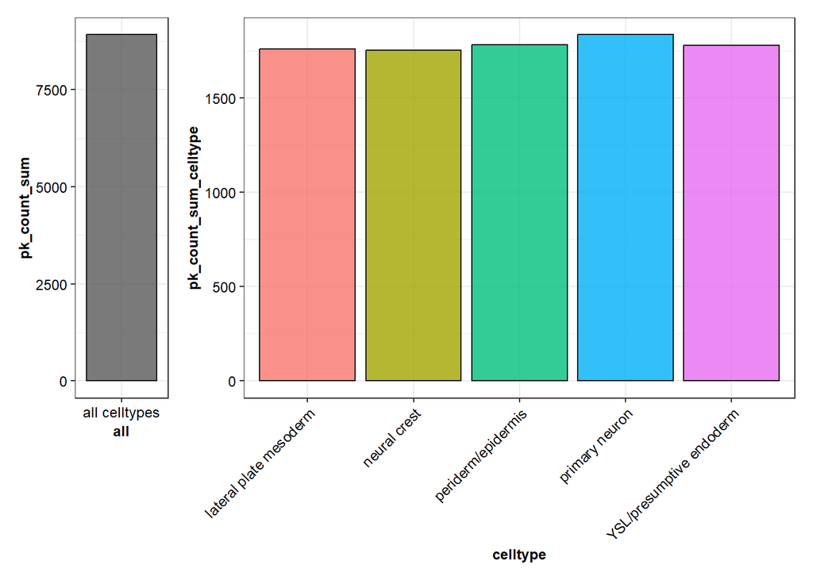

```r
# Overall

df_psd.bulk_atc.lgn %>%
  ungroup() %>%
  distinct(all, pk_count_sum) %>%
  ggplot(aes(x=all, y=pk_count_sum))+
  geom_col(alpha=0.8, color="gray10")+
  coord_fixed(ratio = 0.0005)+
  theme_bw()+ theme(text = element_text(size = 9, family="sans", color="black"), #stylisation
        axis.text = element_text(size=9, color="black"),
        axis.title=element_text(size=9, face = "bold"),
        plot.subtitle=element_text(size=10.5),
        plot.title=element_text(size=11, face = "bold"),
        legend.position ="none") -> sum.peaks.all.lgn


#by cell type

df_psd.bulk_atc.lgn %>%
  group_by(celltype) %>%
  distinct(pk_count_sum_celltype, pk_count_sum) %>%
  ggplot(aes(x=celltype, y=pk_count_sum_celltype, fill=celltype))+
  geom_col(alpha=0.8, color="gray10")+
  theme_bw()+ theme(text = element_text(size = 9, family="sans", color="black"), #stylisation
        axis.text = element_text(size=9, color="black"),
        axis.title=element_text(size=9, face = "bold"),
        axis.text.x = element_text(angle = 45, hjust = 1),
        plot.subtitle=element_text(size=10.5),
        plot.title=element_text(size=11, face = "bold"),
        legend.position ="none") -> sum.peaks.celltype.lgn

sum.peaks.all.lgn|sum.peaks.celltype.lgn
```

Overall, the sum of all peaks is much higher than when the data is normalized with CLR. The sum of all peaks by cell type differs less between each cell type than in CLR-normalized data.

#### 3.2.3.3 Coefficient of variation

Bar plot coefficient of variation.

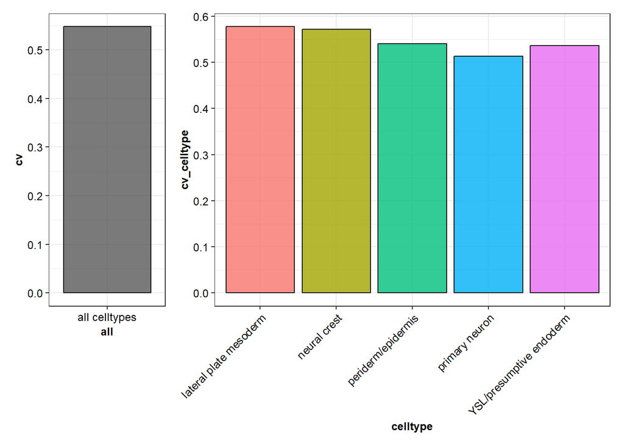

```r
# Overall

df_psd.bulk_atc.lgn %>%
  ungroup() %>%
  distinct(all, cv) %>%
  ggplot(aes(x=all, y=cv ))+
  geom_col(alpha=0.8, color="gray10")+
  scale_y_continuous(n.breaks=10)+
  coord_fixed(ratio = 5)+
  theme_bw()+ theme(text = element_text(size = 9, family="sans", color="black"), #stylisation
        axis.text = element_text(size=9, color="black"),
        axis.title=element_text(size=9, face = "bold"),
        plot.subtitle=element_text(size=10.5),
        plot.title=element_text(size=11, face = "bold"),
        legend.position ="none") -> cv.all.lgn


# by cell type

df_psd.bulk_atc.lgn %>%
  group_by(celltype) %>%
  distinct(cv_celltype, cv) %>%
  ggplot(aes(x=celltype, y=cv_celltype, fill=celltype))+
  geom_col(alpha=0.8, color="gray10")+
  scale_y_continuous(n.breaks=10)+
  theme_bw()+ theme(text = element_text(size = 9, family="sans", color="black"), #stylisation
        axis.text = element_text(size=9, color="black"),
        axis.title=element_text(size=9, face = "bold"),
        axis.text.x = element_text(angle = 45, hjust = 1),
        plot.subtitle=element_text(size=10.5),
        plot.title=element_text(size=11, face = "bold"),
        legend.position ="none") ->cv.celltype.lgn

cv.all.lgn|cv.celltype.lgn
```

The coefficients of variation are very similar to CLR-normalized coefficients of variation although they are slightly reduced overall.

#### 3.2.3.4 Count distribution by cell type

Violin plots

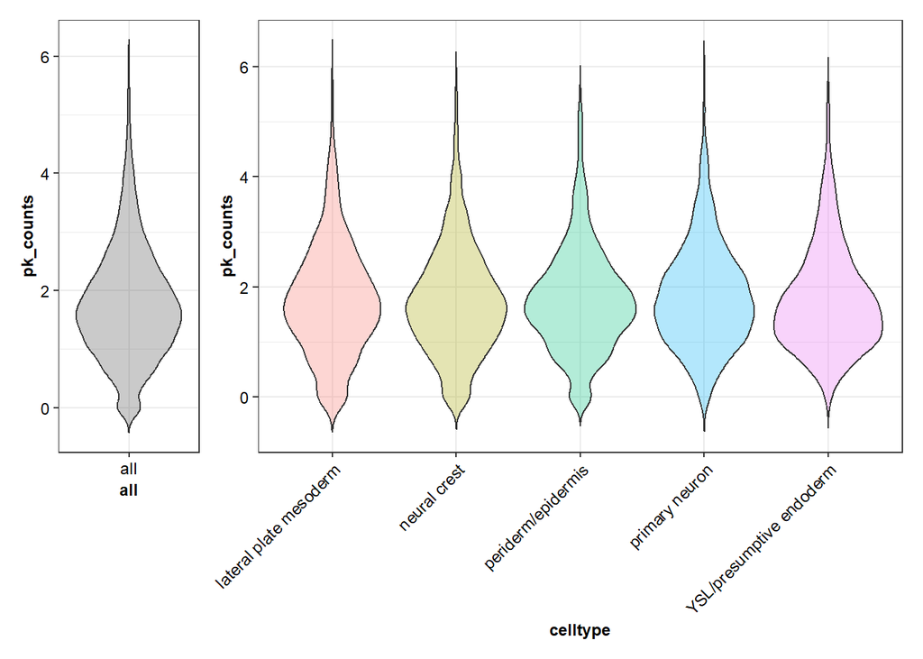

```r
# Overall

df_psd.bulk_atc.lgn %>%
  mutate(all="all") %>%
 ggplot( aes( x=all, y=pk_counts))+
  geom_violin(color="grey20", alpha=0.3, fill="gray30", trim=F)+
  coord_fixed(ratio = 0.5)+
  theme_bw()+ theme(text = element_text(size = 9, family="sans", color="black"), #stylisation
        axis.text = element_text(size=9, color="black"),
        axis.title=element_text(size=9, face = "bold"),
        plot.subtitle=element_text(size=10.5),
        plot.title=element_text(size=11, face = "bold"),
        legend.position ="none") -> v.plot.all.lgn


# by cell type

 ggplot(df_psd.bulk_atc.lgn, aes(x=celltype, y=pk_counts, fill = celltype))+
  geom_violin(color="grey20", alpha=0.3, trim=F)+
  theme_bw()+ theme(text = element_text(size = 9, family="sans", color="black"), #stylisation
        axis.text = element_text(size=9, color="black"),
        axis.text.x = element_text(angle = 45, hjust = 1),
        axis.title=element_text(size=9, face = "bold"),
        plot.subtitle=element_text(size=10.5),
        plot.title=element_text(size=11, face = "bold"),
        legend.position ="none") -> v.plot.cells.lgn

 v.plot.all.lgn|v.plot.cells.lgn
```

Violin plots with a boxplot inside.

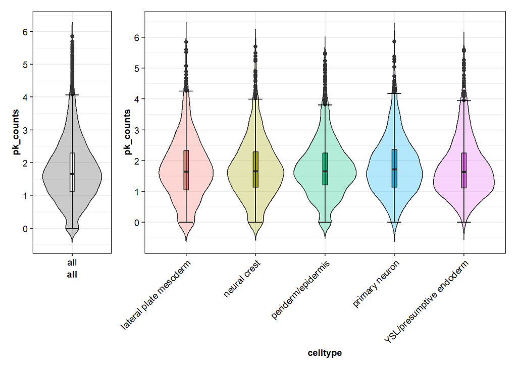

```r
# Overall

df_psd.bulk_atc.lgn %>%
  mutate(all="all") %>%
 ggplot( aes( x=all, y=pk_counts))+
  geom_violin(color="grey20", alpha=0.3, fill="gray30", trim=F)+
  geom_boxplot(width = 0.07)+
  stat_boxplot(geom ='errorbar', width=0.2, position=position_dodge(0.5))+
   scale_y_continuous(breaks = seq(0,10,1))+ #y-axis more easily readable
  coord_fixed(ratio = 0.5)+
  theme_bw()+ theme(text = element_text(size = 9, family="sans", color="black"), #stylisation
        axis.text = element_text(size=9, color="black"),
        axis.title=element_text(size=9, face = "bold"),
        plot.subtitle=element_text(size=10.5),
        plot.title=element_text(size=11, face = "bold"),
        legend.position ="none") -> v.plot.all.box.lgn


# by cell type

 ggplot(df_psd.bulk_atc.lgn, aes(x=celltype, y=pk_counts, fill = celltype))+
  geom_violin(color="grey20", alpha=0.3, trim=F)+
  geom_boxplot(width = 0.07)+
  stat_boxplot(geom ='errorbar', width=0.2, position=position_dodge(0.5))+
    scale_y_continuous(breaks = seq(0,10,1))+ #y-axis more easily readable
  theme_bw()+ theme(text = element_text(size = 9, family="sans", color="black"), #stylisation
        axis.text = element_text(size=9, color="black"),
        axis.text.x = element_text(angle = 45, hjust = 1),
        axis.title=element_text(size=9, face = "bold"),
        plot.subtitle=element_text(size=10.5),
        plot.title=element_text(size=11, face = "bold"),
        legend.position ="none") -> v.plot.cells.box.lgn

 v.plot.all.box.lgn|v.plot.cells.box.lgn
```

The counts are similarily distributed, however values are more centered around count value 1.5. Most counts range from 1 to 3. In contrast to CLR-normalized data the YSL/presumptive endoderm cells do not have slightly higher counts here.

# 4. Summary

For the most part visualization itself works well. Pseudobulking using the Seurat package is successful as well. However, histograms and violin plots of both CLR and LogNormalize from the seurat package show that the data was not sufficiently normalized as most counts are in a range of 0.5 to 2 or 1 to 3. Whereas if the counts were well normalized one would expect most of them to range from 1 to 4. Moreover, out of both Seurat provided options “LogNormalize” yields the results closest to the expectation of well normalized ATAC-seq data.